# **NOTE:** Use File > Save a copy in Drive to make a copy before doing anything else

# Project 7: Data Exploration and Visualization

### Overview

In this project, you will apply data exploration and visualization techniques to a real-world dataset of your choice. You'll practice using pandas for data analysis and create meaningful visualizations to gain insights from your data. This project builds on your Python programming skills while introducing you to the exciting world of data science.

In [Lab7](https://colab.research.google.com/drive/15QvSh0csZaCU-OuuPIfpWx5wLDDjmqK4?usp=sharing), you explore the titanic dataset and you should use it as a sample and pick a dataset of your interest to do a similar data exploration and visualization.

### Project Objectives

- Find and select a dataset from a real-world data source
- Formulate a clear inquiry question based on your chosen dataset
- Perform exploratory data analysis using pandas functions
- Create at least two meaningful data visualizations
- Analyze your findings and answer your inquiry question
- Reflect on the insights gained through data exploration

### Data Sources

You can choose from various online data sources such as:

- [Kaggle](https://www.kaggle.com/datasets) - Wide variety of datasets
- [data.gov](https://www.data.gov/) - U.S. government data
- [Our World in Data](https://ourworldindata.org/) - Global development data
- [GitHub](https://github.com/datasets) - Curated datasets
- [Google Dataset Search](https://datasetsearch.research.google.com/) - Search for datasets
- Or any other reliable data source you find interesting

## Part 1: Dataset Selection and Initial Exploration

#### TODO Tasks:

1. Select Your Dataset: Choose a dataset that interests you. Make sure it has at least 100 rows and multiple columns with different data types (e.g., numerical, categorical, dates).

Please create either text or code cells in between the TODO tasks to do the work.

https://www.kaggle.com/datasets/siddharth0935/himalayan-expeditions

2. Import Libraries: Import the necessary libraries (pandas, matplotlib, seaborn) at the beginning of your notebook by creating code cells below this text cell.

```python
import pandas as pd
import matplotlib.pyplot as plt
import seaborn as sns

sns.set(style="whitegrid")

%matplotlib inline
```

3. Load Your Data: Load your chosen dataset using pandas and save it to a pandas dataframe. Please create a code cell below this text cell to do it.

```python
from google.colab import files
import zipfile
import os

uploaded = files.upload()

zip_filename = next(iter(uploaded))

with zipfile.ZipFile(zip_filename, 'r') as zip_ref:
    zip_ref.extractall()

csv_file = 'exped.csv'

df = pd.read_csv(csv_file)
```

Upload widget is only available when the cell has been executed in the current browser session. Please rerun this cell to enable.

```
Saving archive.zip to archive.zip
```

4. Data Summary: Use the following functions to do inital exploration your dataset:
- info() - Display information about the dataset structure
- describe() - Show statistical summary of numerical columns
- head() - Display the first 5 rows (df.head())
- shape - Show the dimensions of the dataset (e.g. df.shape)
- columns - Get the column names (e.g. df.columns)

You may use 5 code cells below this text cell to accomplish it.

```python
df.info()
```

```
<class 'pandas.core.frame.DataFrame'>
RangeIndex: 11425 entries, 0 to 11424
Data columns (total 65 columns):
 #   Column      Non-Null Count  Dtype
---  ------      --------------  -----
 0   expid       11425 non-null  object
 1   peakid      11425 non-null  object
 2   year        11425 non-null  int64
 3   season      11425 non-null  object
 4   host        11425 non-null  object
 5   route1      11275 non-null  object
 6   route2      360 non-null    object
 7   route3      30 non-null     object
 8   route4      5 non-null      object
 9   nation      11425 non-null  object
```

[output cut: 57 more lines]

```python
df.describe()
```

|  | year | smttime | smtdays | totdays | highpoint | camps | rope | totmembers | smtmembers | mdeaths | tothired | smthired | hdeaths | chksum |
| --- | --- | --- | --- | --- | --- | --- | --- | --- | --- | --- | --- | --- | --- | --- |
| count | 11425.000000 | 4982.00000 | 9671.000000 | 8406.000000 | 11425.000000 | 11425.000000 | 11425.000000 | 11425.000000 | 11425.000000 | 11425.000000 | 11425.000000 | 11425.000000 | 11425.000000 | 1.142500e+04 |
| mean | 2003.120700 | 1073.73605 | 21.488781 | 26.337378 | 7093.530328 | 2.255142 | 172.681225 | 6.123063 | 2.018556 | 0.072035 | 3.157899 | 1.244464 | 0.029322 | 2.295333e+06 |
| std | 15.235501 | 395.92010 | 14.896473 | 15.506469 | 1814.995214 | 1.573960 | 671.047934 | 5.563227 | 3.126758 | 0.366884 | 5.630387 | 2.979685 | 0.275197 | 6.434430e+05 |
| min | 1905.000000 | 14.00000 | 0.000000 | 0.000000 | 0.000000 | 0.000000 | 0.000000 | 0.000000 | 0.000000 | 0.000000 | 0.000000 | 0.000000 | 0.000000 | 2.015000e+03 |
| 25% | 1996.000000 | 829.25000 | 10.000000 | 14.000000 | 6550.000000 | 1.000000 | 0.000000 | 2.000000 | 0.000000 | 0.000000 | 0.000000 | 0.000000 | 0.000000 | 2.452821e+06 |
| 50% | 2007.000000 | 1045.00000 | 19.000000 | 24.000000 | 7200.000000 | 2.000000 | 0.000000 | 5.000000 | 1.000000 | 0.000000 | 2.000000 | 0.000000 | 0.000000 | 2.458388e+06 |
| 75% | 2014.000000 | 1300.00000 | 31.000000 | 37.000000 | 8188.000000 | 3.000000 | 0.000000 | 8.000000 | 3.000000 | 0.000000 | 4.000000 | 1.000000 | 0.000000 | 2.461008e+06 |
| max | 2024.000000 | 8040.00000 | 388.000000 | 280.000000 | 8850.000000 | 34.000000 | 8700.000000 | 99.000000 | 39.000000 | 10.000000 | 99.000000 | 48.000000 | 11.000000 | 2.334512e+07 |

```python
df.head()
```

|  | expid | peakid | year | season | host | route1 | route2 | route3 | route4 | nation | ... | accidents | achievment | agency | comrte | stdrte | primrte | primmem | primref | primid | chksum |
| --- | --- | --- | --- | --- | --- | --- | --- | --- | --- | --- | --- | --- | --- | --- | --- | --- | --- | --- | --- | --- | --- |
| 0 | ANN260101 | ANN2 | 1960 | Spring | Nepal | NW Ridge-W Ridge | NaN | NaN | NaN | UK | ... | NaN | NaN | NaN | False | False | False | False | False | NaN | 2442047 |
| 1 | ANN269301 | ANN2 | 1969 | Autumn | Nepal | NW Ridge-W Ridge | NaN | NaN | NaN | Yugoslavia | ... | Draslar frostbitten hands and feet | NaN | NaN | False | False | False | False | False | NaN | 2445501 |
| 2 | ANN273101 | ANN2 | 1973 | Spring | Nepal | W Ridge-N Face | NaN | NaN | NaN | Japan | ... | NaN | NaN | NaN | False | False | False | False | False | NaN | 2446797 |
| 3 | ANN278301 | ANN2 | 1978 | Autumn | Nepal | N Face-W Ridge | NaN | NaN | NaN | UK | ... | NaN | NaN | NaN | False | False | False | False | False | NaN | 2448822 |
| 4 | ANN279301 | ANN2 | 1979 | Autumn | Nepal | N Face-W Ridge | NW Ridge of A-IV | NaN | NaN | UK | ... | NaN | NaN | NaN | False | False | False | False | False | NaN | 2449204 |

5 rows × 65 columns

```python
df.shape
```

```
(11425, 65)
```

```python
df.columns
```

```
Index(['expid', 'peakid', 'year', 'season', 'host', 'route1', 'route2',
       'route3', 'route4', 'nation', 'leaders', 'sponsor', 'success1',
       'success2', 'success3', 'success4', 'ascent1', 'ascent2', 'ascent3',
       'ascent4', 'claimed', 'disputed', 'countries', 'approach', 'bcdate',
       'smtdate', 'smttime', 'smtdays', 'totdays', 'termdate', 'termreason',
       'termnote', 'highpoint', 'traverse', 'ski', 'parapente', 'camps',
       'rope', 'totmembers', 'smtmembers', 'mdeaths', 'tothired', 'smthired',
       'hdeaths', 'nohired', 'o2used', 'o2none', 'o2climb', 'o2descent',
       'o2sleep', 'o2medical', 'o2taken', 'o2unkwn', 'othersmts', 'campsites',
       'accidents', 'achievment', 'agency', 'comrte', 'stdrte', 'primrte',
       'primmem', 'primref', 'primid', 'chksum'],
      dtype='object')
```

5. Inquiry Question: Write a clear, specific question that you want to answer using your dataset by creating a text cell below and **write the question in bold please.**

For example:

- "How has the average temperature changed in major cities over the past decade?"
- "What factors are most strongly correlated with housing prices?"
- "Is there a relationship between education level and income?"

**Is there a relationship between which season the expedition in the Himilayas takes place and the success rate of reaching the peak?**

## Part 2: Data Visualization and Analysis

#### TODO Tasks:

1. Data Cleaning (if necessary): Check for and handle any missing values, duplicates, or data quality issues.

**NOTE: This could be a daunting task even for seasoned data scientists. My suggestion is to use a dataset that is already clean if you can for the purpose of completing this assignment in a week.**

Examples:

- Checking for missing values: df.isnull().sum()
- Dropping rows with any missing values: df.dropna(inplace=True)
- Dropping columns with all missing values: df.dropna(axis=1, how='all', inplace=True)
- Removing duplicate row: df.drop_duplicates(inplace=True)

```python
print(df.isnull().sum()) # Print the number of missing values in each column

df_clean = df.drop(columns=['primid']) # Drop the primid column (not needed too many missing values)

df_clean = df_clean.drop_duplicates() # Remove duplicate rows

print(f"Shape before cleaning: {df.shape}") # Show original number of rows and columns
print(f"Shape after cleaning: {df_clean.shape}") # Show shape after cleaning
```

```
expid          0
peakid         0
year           0
season         0
host           0
           ...
primrte        0
primmem        0
primref        0
primid     10672
chksum         0
Length: 65, dtype: int64
Shape before cleaning: (11425, 65)
Shape after cleaning: (11425, 64)
```

2. Create Visualizations: Create at least 2 different types of visualizations that help answer your research question. Choose from:
- Bar charts
- Line plots
- Scatter plots
- Histograms
- Box plots
- Heatmaps
- Any other appropriate visualization
3. Customize Your Plots: Make sure your visualizations are clear and informative by:
- Adding appropriate titles
- Labeling axes
- Using colors effectively
- Adding legends when necessary

Please create code cells below this to create your visualizations.

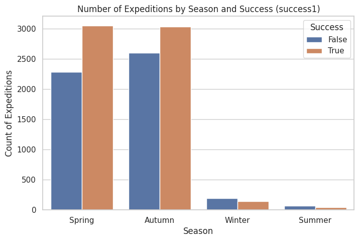

```python
df_filtered = df_clean[df_clean['season'] != 'Unknown'] # Remove rows with unknown season

plt.figure(figsize=(8,5)) # Set the size of the plot
sns.countplot(data=df_filtered, x='season', hue='success1') # Create bar chart grouped by season and success
plt.title('Number of Expeditions by Season and Success (success1)')
plt.xlabel('Season')
plt.ylabel('Count of Expeditions')
plt.legend(title='Success')
plt.show()
```

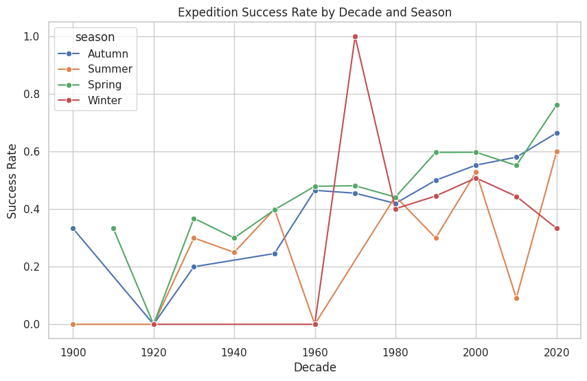

```python
df_filtered = df_clean[df_clean['season'] != 'Unknown'].copy() # Remove rows with unknown season
df_filtered['decade'] = (df_filtered['year'] // 10) * 10 # Create decade column

decade_season_success = (
    df_filtered.groupby(['decade', 'season']) # Group by decade and season
    .agg(success_rate=('success1', 'mean')) # Calculate mean success rate
    .reset_index() # Reset index for plotting
)

plt.figure(figsize=(10,6))
sns.lineplot(data=decade_season_success, x='decade', y='success_rate', hue='season', marker='o') # Plot line chart
plt.title('Expedition Success Rate by Decade and Season')
plt.xlabel('Decade')
plt.ylabel('Success Rate')
plt.show()
```

4. Analysis: Write 1-2 paragraphs discussing:
- Whether your research question can be answered with the available data
- What insights you discovered through your visualizations
- Any unexpected or interesting findings
- Limitations of your analysis
- Suggestions for further investigation

Please create a text cell below this cell to write your analysis.

My original question was: Is there a relationship between which season the expedition in the Himilayas takes place and the success rate of reaching the peak? This can be answered clearly by the visualizations created using this data set.

In the bar graph I compared the number of successes recorded during each of the four seasons. Since it was stored as a boolean, the bar graph was the best choice here to compare success vs failure. The conclusion that can be drawn here is that the season is a huge factor in influencing the success rate. spring and autumn have immensely more expeditions than summer and winter. Because of this we can assume that it is more risky to do expeditions in the summer and winter, and that assumption is correct as the failure rate is higher than the success rate in those two seasons. Additionally in the other two (spring and autumn) the success rate is higher than the failure rate.

## NOTE: If you use a local dataset, you MUST submit the dataset along with your notebook to get credit.

- Download your notebook as CS110_Project7.ipynb
- Ensure all TODO tasks are completed
- Make sure your code runs without errors
- Include clear comments explaining your work
- Submit the notebook file

## Grading Criteria (4 points)

- Dataset Selection: Appropriate choice of dataset with sufficient complexity
- Inquiry Question: Clear, specific, and answerable with the chosen data
- Data Exploration: Proper use of pandas functions for initial analysis
- Visualizations: At least 2 clear, well-formatted, and relevant plots
- Analysis: Thoughtful interpretation of findings and answer to research question
- Code Quality: Clean, commented, and well-organized code

Remember: The goal is not just to create visualizations, but to use them to gain meaningful insights about your data. Think like a data scientist and let your curiosity guide your exploration!